# writeup

Logan King

10/26/2020

# Modeling the unknown distribution with maximum likelihood and method of moments

Maximum likelihood (MLE) and method of moments (MM) are two common methods for constructing a model.

The following tutorial will explain how one might use MLE and MM to model (a) Glycohemoglobin and (b) Height of adult females.

The data is from the National Health and Nutrition Examination Survey 2009-2010 (NHANES), available from the Hmisc package.

## Data

```r
library(tidyverse)
library(stats4)
library(knitr)
```

```r
Hmisc::getHdata(nhgh)
d1 <- nhgh %>%
  filter(sex == "female") %>%
  filter(age >= 18) %>%
  select(gh, ht)
```

```r
set.seed(8)
```

# Glycohemoglobin

## MLE

### Estimates of Parameters

```r
norm_LL <- function(mean, sd) {
  fs = dnorm(
    x = d1$gh,
    mean = mean,
    sd = sd,
    log = T
  )
  -sum(fs)
}

norm_fit <- mle(
  norm_LL,
  start = list(mean = 1, sd = 1),
  method = 'L-BFGS-B',
  lower = c(0, .01)
)

mle_norm_mean <- norm_fit@coef[1]
mle_norm_sd <- norm_fit@coef[2]

gamma_LL <- function(shape, scale) {
  fs = dgamma(
    x = d1$gh,
    shape = shape,
    scale = scale,
    log = T
  )
  -sum(fs)
}

gamma_fit <- mle(
  gamma_LL,
  start = list(shape = 1, scale = 1),
  method = 'L-BFGS-B',
  lower = c(0, .01)
)

mle_gamma_shape <- gamma_fit@coef[1]
mle_gamma_scale <- gamma_fit@coef[2]


weib_LL <- function(shape, scale) {
  fs = dweibull(
    x = d1$gh,
    shape = shape,
    scale = scale,
    log = T
  )
  -sum(fs)
}

weib_fit <- mle(
  weib_LL,
  start = list(shape = 1, scale = 1),
  method = 'L-BFGS-B',
  lower = c(0, .01)
)

mle_weib_shape <- weib_fit@coef[1]
mle_weib_scale <- weib_fit@coef[2]
```

### Overlay estimated pdf onto histogram

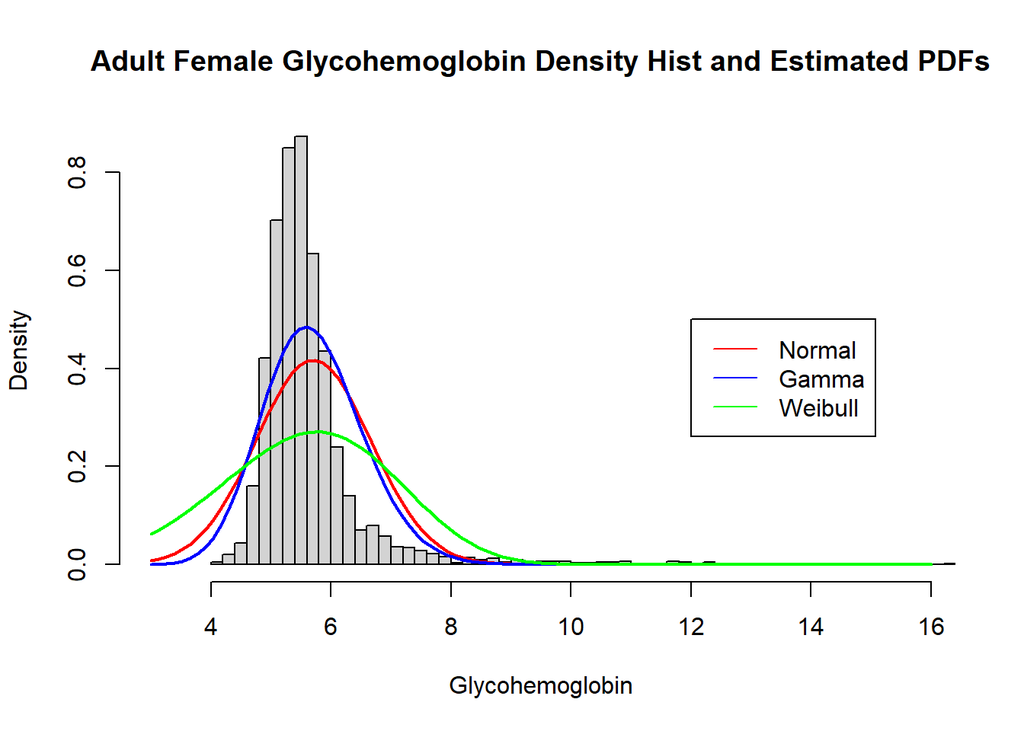

```r
hist(d1$gh, breaks = 50, freq = F, xlim = c(3,16),
     main = 'Adult Female Glycohemoglobin Density Hist and Estimated PDFs',
     xlab = 'Glycohemoglobin')
curve(dnorm(x, mean = mle_norm_mean, sd = mle_norm_sd), add = T, col = 'red', lwd = 2)
curve(dgamma(x, shape = mle_gamma_shape, scale = mle_gamma_scale), add = T, col = 'blue', lwd = 2)
curve(dweibull(x, shape = mle_weib_shape, scale = mle_weib_scale), add = T, col = 'green', lwd = 2)
legend(12, .5, legend = c('Normal', 'Gamma', 'Weibull'), col = c('red', 'blue', 'green'), lty = 1)
```

From the overlay of the density estimates onto the glycohemoglobin PDF, we observe that none of the distribution estimates is necessarily a good fit for the actual distribution. However, we can tell that the normal and gamma are clearly better fits than the weibull distribution.

### Overlay estimated CDF onto eCDF

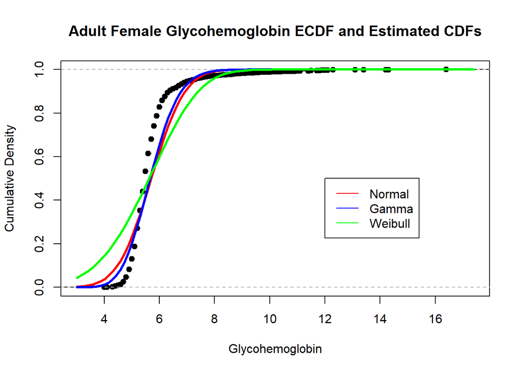

```r
plot(ecdf(d1$gh),
     main = 'Adult Female Glycohemoglobin ECDF and Estimated CDFs',
     xlab = 'Glycohemoglobin',
     ylab = 'Cumulative Density')
curve(pnorm(x, mean = mle_norm_mean, sd = mle_norm_sd), add = T, col = 'red', lwd = 3)
curve(pgamma(x, shape = mle_gamma_shape, scale = mle_gamma_scale), add = T, col = 'blue', lwd = 3)
curve(pweibull(x, shape = mle_weib_shape, scale = mle_weib_scale), add = T, col = 'green', lwd = 3)
legend(12, .5, legend = c('Normal', 'Gamma', 'Weibull'), col = c('red', 'blue', 'green'), lty = 1)
```

From the above plot of the CDF estimates against the ECDF, our findings from the previous histogram and PDF plot are further confirmed. None of the estimates are necessarily a good fit, but both normal and gamma outperform the weibull estimate.

### QQ plot (sample vs estimated dist)

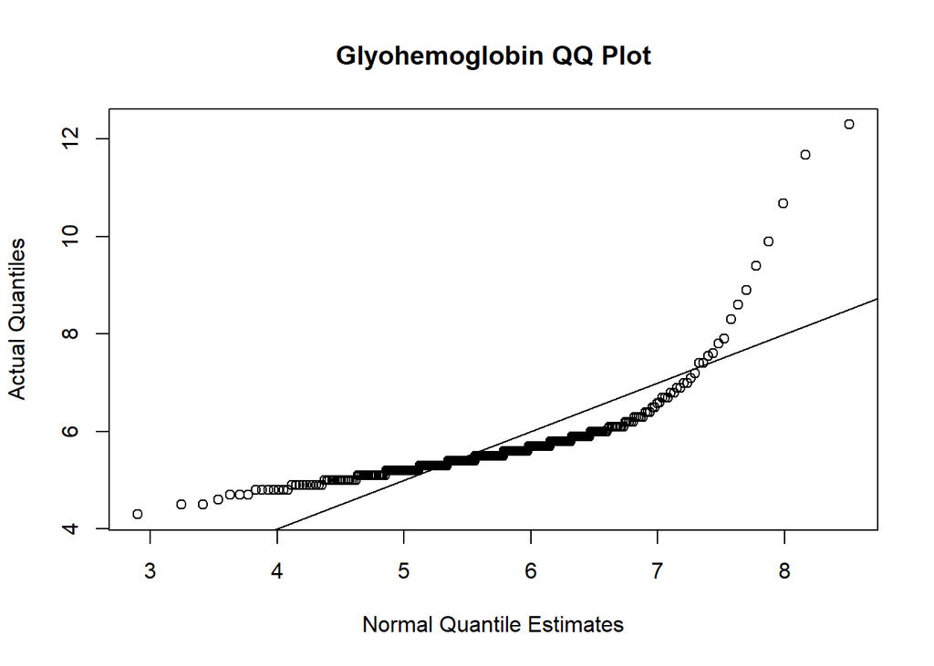

```r
p = ppoints(300)
y = quantile(d1$gh, probs = p)

qqplot(qnorm(p, mean = mle_norm_mean, sd = mle_norm_sd), y,
       main = 'Glyohemoglobin QQ Plot',
       xlab = 'Normal Quantile Estimates',
       ylab = 'Actual Quantiles')
abline(0,1)
```

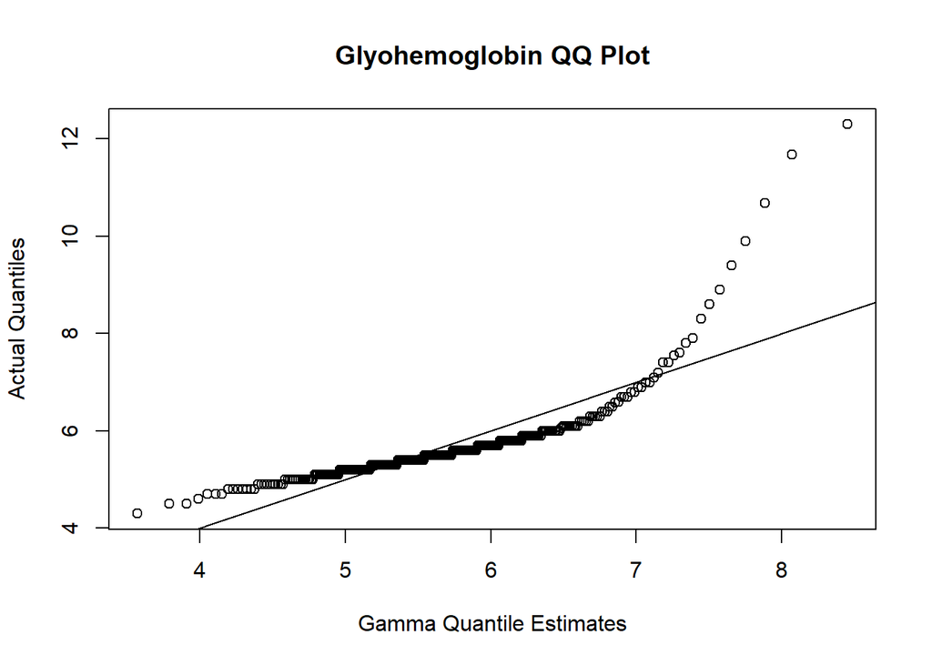

```r
qqplot(qgamma(p, shape = mle_gamma_shape, scale = mle_gamma_scale), y,
       main = 'Glyohemoglobin QQ Plot',
       xlab = 'Gamma Quantile Estimates',
       ylab = 'Actual Quantiles')
abline(0,1)
```

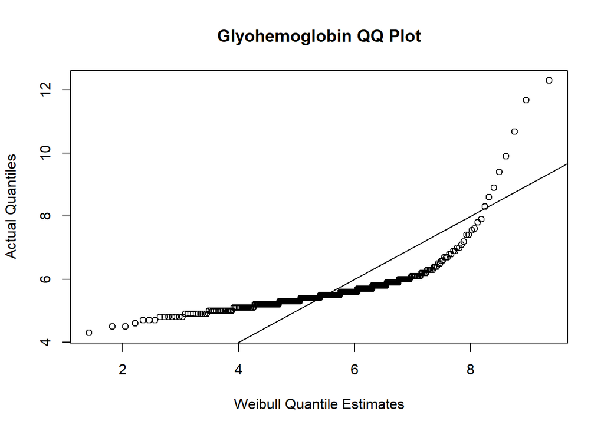

```r
qqplot(qweibull(p, shape = mle_weib_shape, scale = mle_weib_scale), y,
       main = 'Glyohemoglobin QQ Plot',
       xlab = 'Weibull Quantile Estimates',
       ylab = 'Actual Quantiles')
abline(0,1)
```

The QQ plots again confirm previous findings. Each distribution struggles to conform to the line of identity, although the gamma appears to remain tightest to the identity line in the middle of the distribution. Each distribution is extremely inaccurate at the tails.

### Estimated Median

The median of each distribution is calculated by finding the quantile value at .5 for each distribution. While previously viewed as the poorest fit, the weibull distribution actually has the closest median value to the actual sample.

```r
medians <- cbind(c('Actual', 'Normal', 'Gamma', 'Weibull'),
      c(median(d1$gh) %>% round(3),
        qnorm(.5, mean = mle_norm_mean, sd = mle_norm_sd) %>% round(3),
        qgamma(.5, shape = mle_gamma_shape, scale = mle_gamma_scale) %>% round(3),
        qweibull(.5, shape = mle_weib_shape, scale = mle_weib_scale) %>% round(3))) %>% as.data.frame()

medians[,2] <- medians[,2] %>% as.numeric()

names(medians) <- c('Distribution Estimate', 'Median')

kable(medians)
```

| Distribution Estimate | Median |
| --- | --- |
| Actual | 5.500 |
| Normal | 5.705 |
| Gamma | 5.665 |
| Weibull | 5.629 |

### Median Samp Dist (hist)

```r
medians_norm <- NA
for(i in 1:10000) {
  medians_norm[i] = rnorm(nrow(d1), mean = mle_norm_mean, sd = mle_norm_sd) %>% median()
}

medians_gamma <- NA
for(i in 1:10000) {
  medians_gamma[i] = rgamma(nrow(d1), shape = mle_gamma_shape, scale = mle_gamma_scale) %>% median()
}

medians_weib <- NA
for(i in 1:10000) {
  medians_weib[i] = rweibull(nrow(d1), shape = mle_weib_shape, scale = mle_weib_scale) %>% median()
}
```

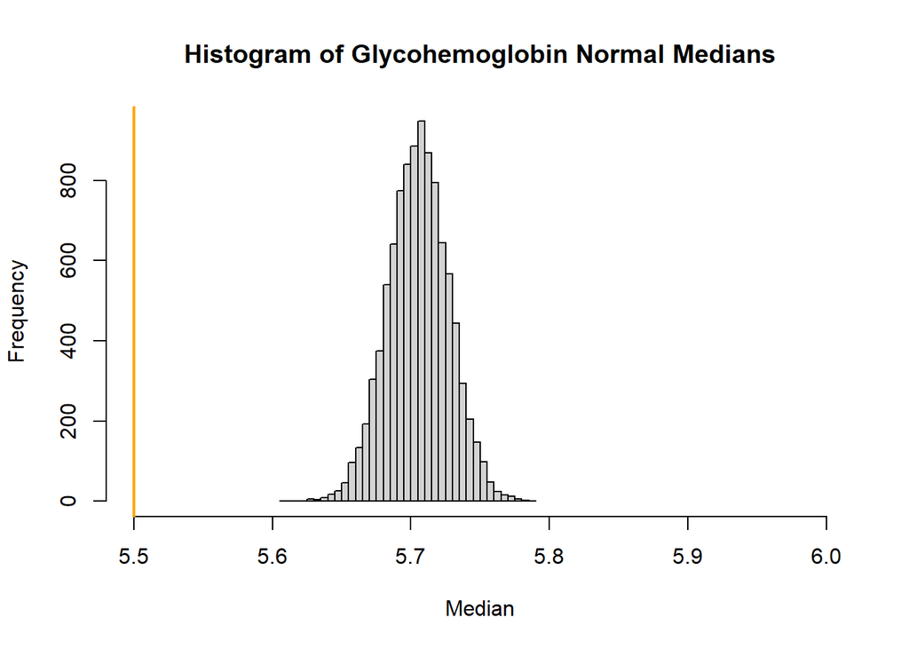

```r
hist(medians_norm, breaks = 50, xlim = c(median(d1$gh), 6),
     main = 'Histogram of Glycohemoglobin Normal Medians',
     xlab = 'Median')
abline(v = median(d1$gh), col = 'orange', lwd = 2)
```

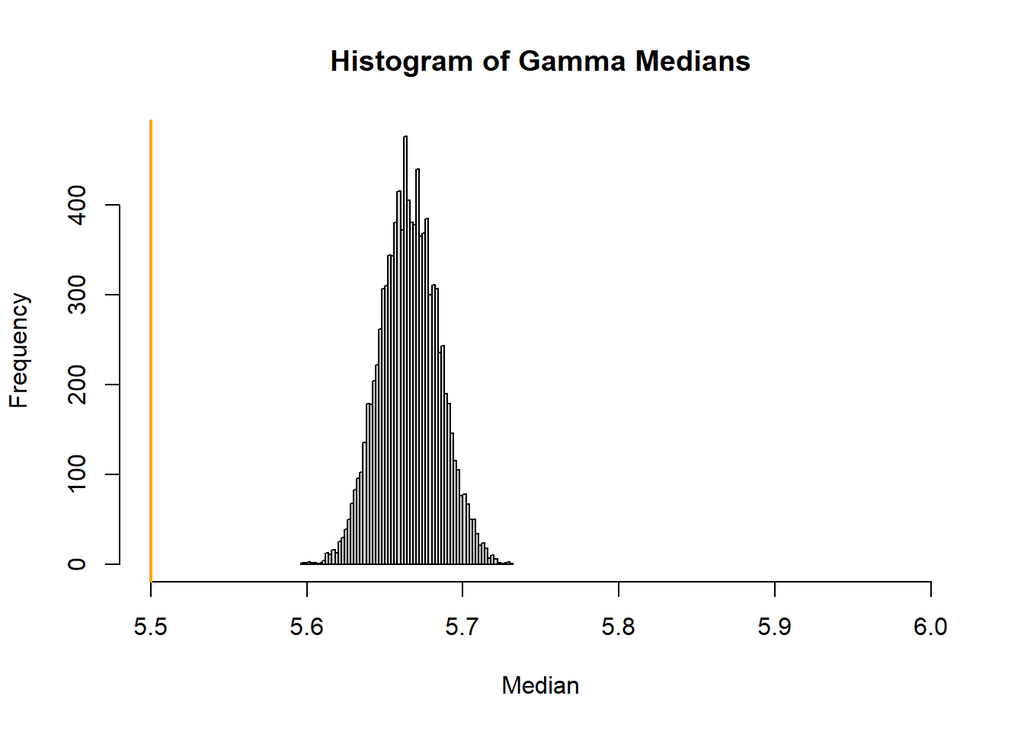

```r
hist(medians_gamma, breaks = 50, xlim = c(median(d1$gh), 6),
     main = 'Histogram of Gamma Medians',
     xlab = 'Median')
abline(v = median(d1$gh), col = 'orange', lwd = 2)
```

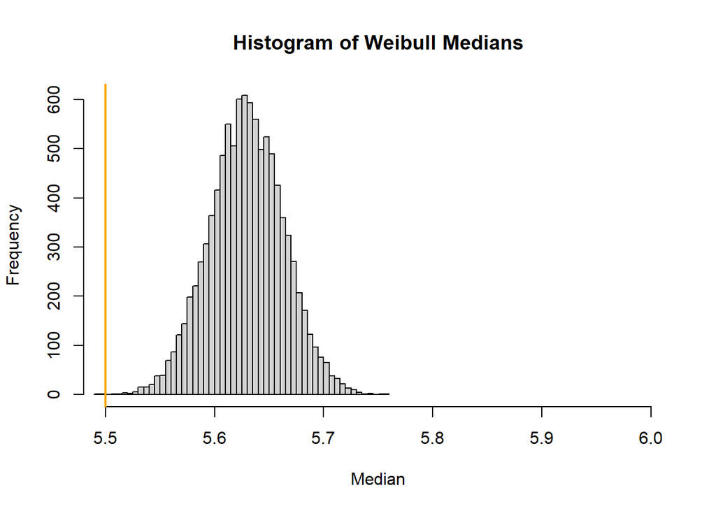

```r
hist(medians_weib, breaks = 50, xlim = c(median(d1$gh), 6),
     main = 'Histogram of Weibull Medians',
     xlab = 'Median')
abline(v = median(d1$gh), col = 'orange', lwd = 2)
```

Generating 10000 samples of each distribution estimate and taking the median of each allows us to generate a sampling distribution of the medians to compare to the actual median. We see that the weibull distribution is the only one that succeeds in capturing the actual median of the sample, while the normal and gamma median sampling distributions overshoot the actual median of the sample.

### Range of middle 95% of Median Samp Dist

```r
dist_est <- c('Normal', 'Gamma', 'Weibull')
middle_95 <- rbind(quantile(medians_norm, probs = c(.025, .975)),
                   quantile(medians_gamma, probs = c(.025, .975)),
                   quantile(medians_weib, probs = c(.025, .975))) %>% as.data.frame()

middle_95_dist <- cbind(dist_est, middle_95) %>%
  mutate(`Distribution Estimate` = dist_est,
         `2.5%` = `2.5%` %>% round(3),
         `97.5%` = `97.5%` %>% round(3),
         Range = `97.5%` - `2.5%`,
         `Actual Median Contained` = ifelse(`2.5%` <= median(d1$gh) & `97.5%` >= median(d1$gh), T, F)) %>%
  select(`Distribution Estimate`, `2.5%`, `97.5%`, Range, `Actual Median Contained`)

kable(middle_95_dist)
```

| Distribution Estimate | 2.5% | 97.5% | Range | Actual Median Contained |
| --- | --- | --- | --- | --- |
| Normal | 5.662 | 5.748 | 0.086 | FALSE |
| Gamma | 5.629 | 5.703 | 0.074 | FALSE |
| Weibull | 5.562 | 5.696 | 0.134 | FALSE |

We can calculate the middle 95% of the median sampling distributions by taking the quantiles at .025 and .975 for each of the median sampling distributions. We observe the gamma distribution to have the tightest interval - it is the most precise - while the range weibull distribution exceeds both the gamma and normal ranges by a significant margin. We see that the actual median is not contained in any of the 95% confidence intervals - none of the intervals are accurate. While the median sampling distribution for the weibull distribution did contain the actual median, it is not contained within the 95% confidence interval, so we can’t be certain that the median will be within the weibull distribution every time it is simulated.

## MM

### Estimates of Parameters

For the method of moments, each parameter is estimated based on the distribution’s relevant parameter function. For the normal distribution, we take the mean and standard deviation of the sample to estimate the mean and standard deviation of the distribution. A similar approach is taken to estimate the shape and scale of the gamma distribution: the sample mean squared divided by the sample variance estimates the gamma shape while the sample variance divided by the sample mean estimates the gamma scale. Weibull estimates are also developed similarly, however a system of equations must be set up and solved for to obtain the shape and scale estimates.

```r
mm_norm_mean <- mean(d1$gh)
mm_norm_sd <- sd(d1$gh)

mm_gamma_shape <- (mean(d1$gh) ^ 2) / var(d1$gh)
mm_gamma_scale <- var(d1$gh) / mean(d1$gh)

weib_lambda <- function(samp_mean, k) {
  samp_mean / gamma(1 + (1 / k))
}

weib_var_func <- function(samp_mean, samp_var, k) {
  ((weib_lambda(samp_mean, k) ^ 2) * (gamma(1 + (2 / k)) - (gamma(1 + (1 / k)) ^ 2))) - samp_var
}

weib_optimize <- optimize(f = function(x) {abs(weib_var_func(samp_mean = mean(d1$gh), samp_var = var(d1$gh), k = x))},
                          lower = 0, upper = 100)

mm_weib_shape <- weib_optimize$minimum

mm_weib_scale <- weib_lambda(samp_mean = mean(d1$gh), k = mm_weib_shape)
```

### Overlay estimated pdf onto histogram

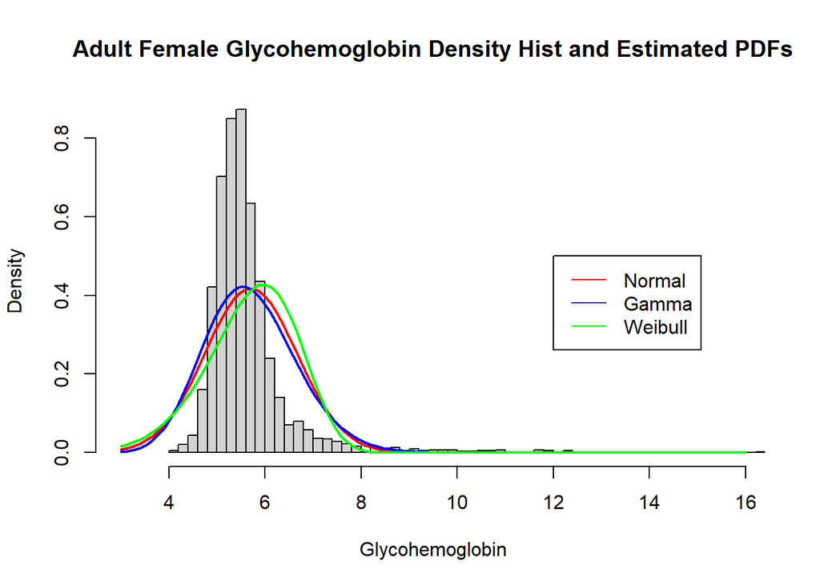

```r
hist(d1$gh, breaks = 50, freq = F, xlim = c(3,16),
     main = 'Adult Female Glycohemoglobin Density Hist and Estimated PDFs',
     xlab = 'Glycohemoglobin')
curve(dnorm(x, mean = mm_norm_mean, sd = mm_norm_sd), add = T, col = 'red', lwd = 2)
curve(dgamma(x, shape = mm_gamma_shape, scale = mm_gamma_scale), add = T, col = 'blue', lwd = 2)
curve(dweibull(x, shape = mm_weib_shape, scale = mm_weib_scale), add = T, col = 'green', lwd = 2)
legend(12, .5, legend = c('Normal', 'Gamma', 'Weibull'), col = c('red', 'blue', 'green'), lty = 1)
```

From the overlay of the density estimates onto the glycohemoglobin PDF, we observe that none of the distribution estimates is necessarily a good fit for the actual distribution. The distributions estimated using method of moments don’t provide the great disparity between normal/gamma and weibull that was seen with the MLE estimates, however normal and gamma appear as slightly more reliable fits.

### Overlay estimated CDF onto eCDF

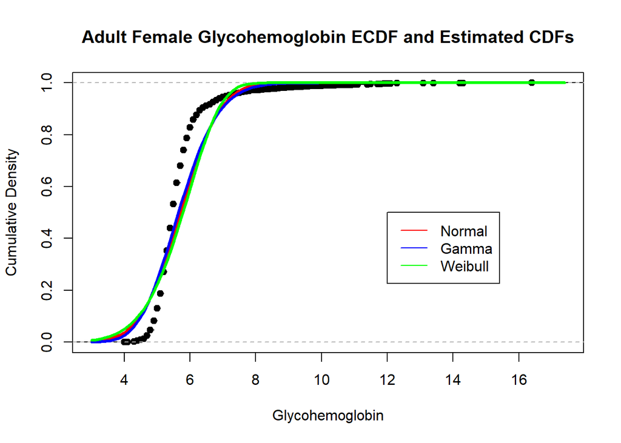

```r
plot(ecdf(d1$gh),
     main = 'Adult Female Glycohemoglobin ECDF and Estimated CDFs',
     xlab = 'Glycohemoglobin',
     ylab = 'Cumulative Density')
curve(pnorm(x, mean = mm_norm_mean, sd = mm_norm_sd), add = T, col = 'red', lwd = 3)
curve(pgamma(x, shape = mm_gamma_shape, scale = mm_gamma_scale), add = T, col = 'blue', lwd = 3)
curve(pweibull(x, shape = mm_weib_shape, scale = mm_weib_scale), add = T, col = 'green', lwd = 3)
legend(12, .5, legend = c('Normal', 'Gamma', 'Weibull'), col = c('red', 'blue', 'green'), lty = 1)
```

From the above plot of the CDF estimates against the ECDF, our findings from the previous histogram and PDF plot are further confirmed. None of the estimates are a good fit, but normal and gamma are slightly better fits than the weibull distribution.

### QQ plot (sample vs estimated dist)

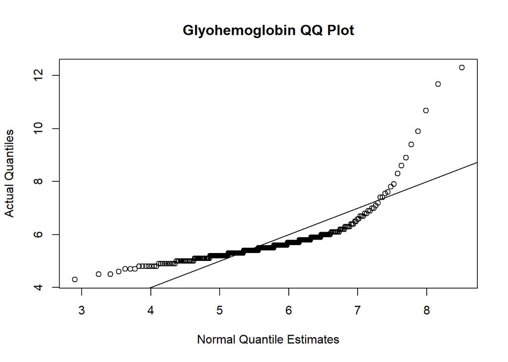

```r
p = ppoints(300)
y = quantile(d1$gh, probs = p)

qqplot(qnorm(p, mean = mm_norm_mean, sd = mm_norm_sd), y,
       main = 'Glyohemoglobin QQ Plot',
       xlab = 'Normal Quantile Estimates',
       ylab = 'Actual Quantiles')
abline(0,1)
```

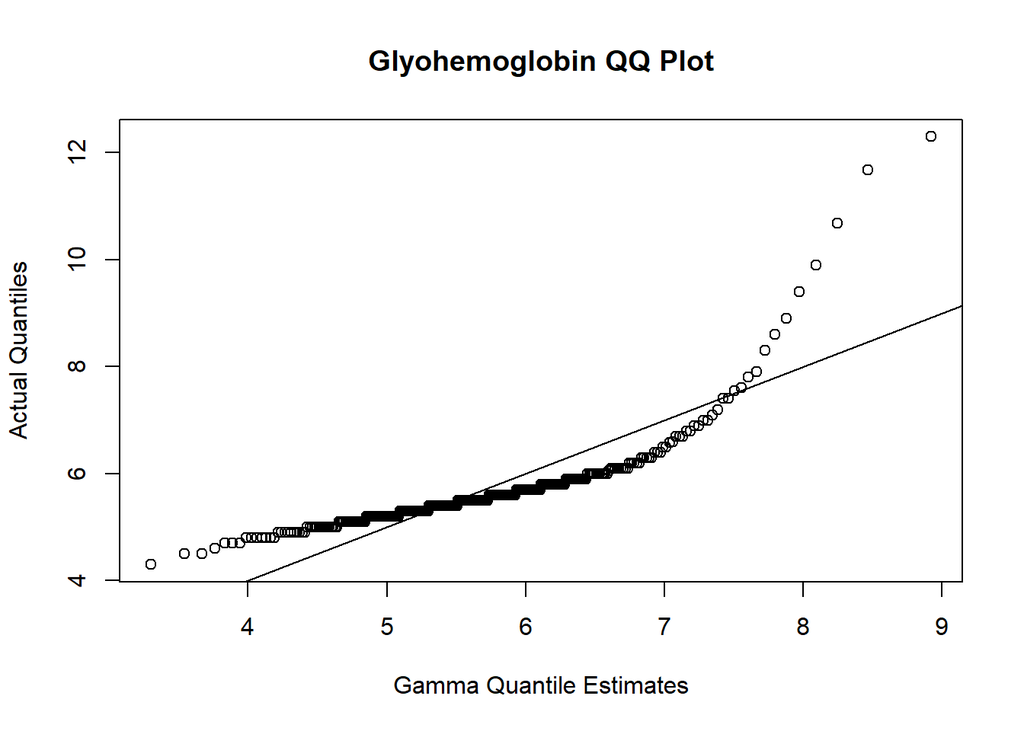

```r
qqplot(qgamma(p, shape = mm_gamma_shape, scale = mm_gamma_scale), y,
       main = 'Glyohemoglobin QQ Plot',
       xlab = 'Gamma Quantile Estimates',
       ylab = 'Actual Quantiles')
abline(0,1)
```

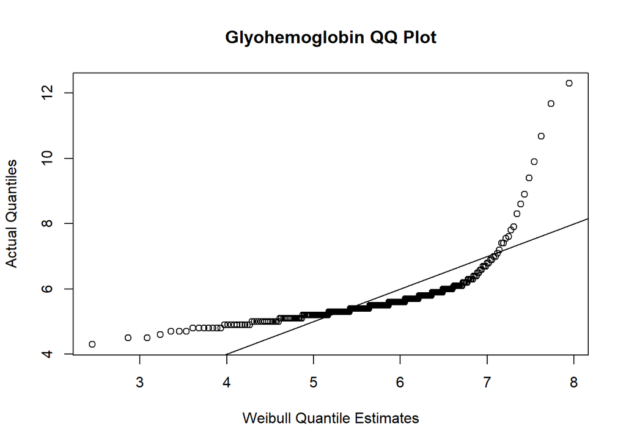

```r
qqplot(qweibull(p, shape = mm_weib_shape, scale = mm_weib_scale), y,
       main = 'Glyohemoglobin QQ Plot',
       xlab = 'Weibull Quantile Estimates',
       ylab = 'Actual Quantiles')
abline(0,1)
```

The QQ plots again confirm previous findings. Each distribution struggles to conform to the line of identity and each distribution is extremely inaccurate at the tails.

### Estimated Median

The median of each distribution is calculated by finding the quantile value at .5 for each distribution. The gamma distribution provides the closest median value to the actual sample, but each distribution overshoots the actual median value.

```r
medians <- cbind(c('Actual', 'Normal', 'Gamma', 'Weibull'),
      c(median(d1$gh) %>% round(3),
        qnorm(.5, mean = mm_norm_mean, sd = mm_norm_sd) %>% round(3),
        qgamma(.5, shape = mm_gamma_shape, scale = mm_gamma_scale) %>% round(3),
        qweibull(.5, shape = mm_weib_shape, scale = mm_weib_scale) %>% round(3))) %>% as.data.frame()

medians[,2] <- medians[,2] %>% as.numeric()

names(medians) <- c('Distribution Estimate', 'Median')

kable(medians)
```

| Distribution Estimate | Median |
| --- | --- |
| Actual | 5.500 |
| Normal | 5.705 |
| Gamma | 5.652 |
| Weibull | 5.788 |

### Median Samp Dist (hist)

```r
medians_norm <- NA
for(i in 1:10000) {
  medians_norm[i] = rnorm(nrow(d1), mean = mm_norm_mean, sd = mm_norm_sd) %>% median()
}

medians_gamma <- NA
for(i in 1:10000) {
  medians_gamma[i] = rgamma(nrow(d1), shape = mm_gamma_shape, scale = mm_gamma_scale) %>% median()
}

medians_weib <- NA
for(i in 1:10000) {
  medians_weib[i] = rweibull(nrow(d1), shape = mm_weib_shape, scale = mm_weib_scale) %>% median()
}
```

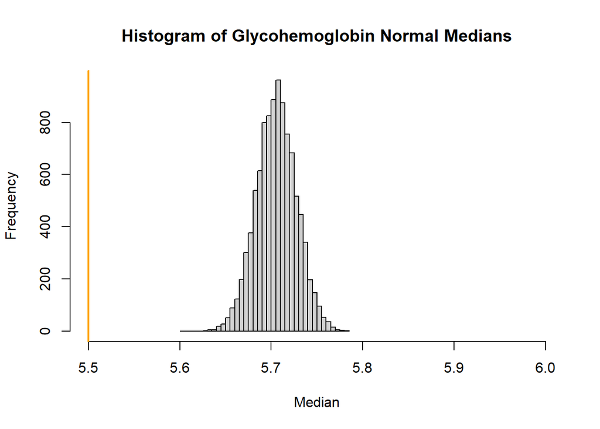

```r
hist(medians_norm, breaks = 50, xlim = c(median(d1$gh), 6),
     main = 'Histogram of Glycohemoglobin Normal Medians',
     xlab = 'Median')
abline(v = median(d1$gh), col = 'orange', lwd = 2)
```

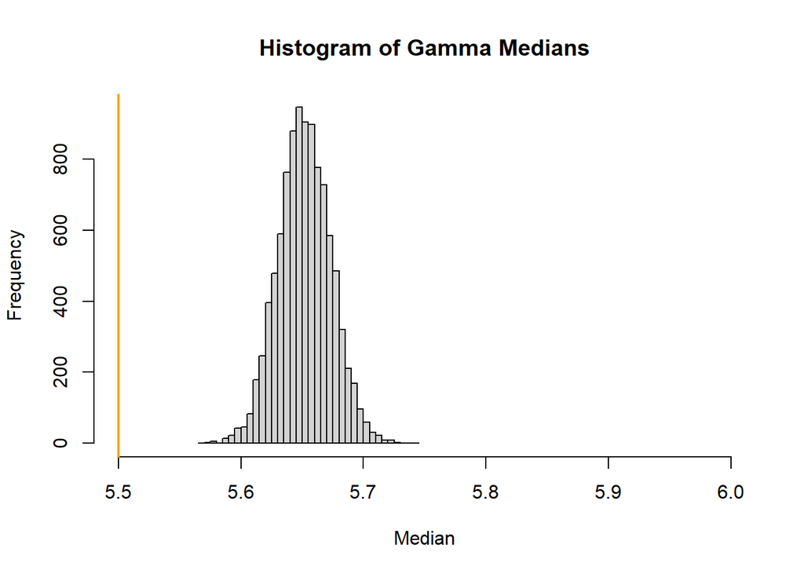

```r
hist(medians_gamma, breaks = 50, xlim = c(median(d1$gh), 6),
     main = 'Histogram of Gamma Medians',
     xlab = 'Median')
abline(v = median(d1$gh), col = 'orange', lwd = 2)
```

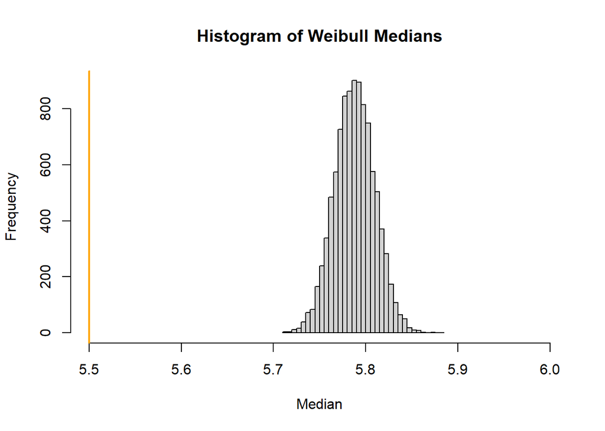

```r
hist(medians_weib, breaks = 50, xlim = c(median(d1$gh), 6),
     main = 'Histogram of Weibull Medians',
     xlab = 'Median')
abline(v = median(d1$gh), col = 'orange', lwd = 2)
```

Once again using simulation to generate medians, we observe the estimated median sampling distribution as compared to the actual median. Each distribution fails to capture the actual sample median in its sampling distribution, but we see the gamma distribution as closest to the actual value, confirming the above median table.

### Range of middle 95% of Median Samp Dist

```r
dist_est <- c('Normal', 'Gamma', 'Weibull')
middle_95 <- rbind(quantile(medians_norm, probs = c(.025, .975)),
                   quantile(medians_gamma, probs = c(.025, .975)),
                   quantile(medians_weib, probs = c(.025, .975))) %>% as.data.frame()

middle_95_dist <- cbind(dist_est, middle_95) %>%
  mutate(`Distribution Estimate` = dist_est,
         `2.5%` = `2.5%` %>% round(3),
         `97.5%` = `97.5%` %>% round(3),
         Range = `97.5%` - `2.5%`,
         `Actual Median Contained` = ifelse(`2.5%` <= median(d1$gh) & `97.5%` >= median(d1$gh), T, F)) %>%
  select(`Distribution Estimate`, `2.5%`, `97.5%`, Range, `Actual Median Contained`)

kable(middle_95_dist)
```

| Distribution Estimate | 2.5% | 97.5% | Range | Actual Median Contained |
| --- | --- | --- | --- | --- |
| Normal | 5.662 | 5.748 | 0.086 | FALSE |
| Gamma | 5.611 | 5.694 | 0.083 | FALSE |
| Weibull | 5.746 | 5.831 | 0.085 | FALSE |

We can calculate the middle 95% of the median sampling distributions by taking the quantiles at .025 and .975 for each of the median sampling distributions. Unlike the MLE method, the range of every confidence interval is similar - they all hold similar precision. We still find that the median is not contained in any of the distributions’ confidence intervals - none are accurate. We see that the weibull distribution interval lies higher than the normal and gamma intervals - further away from the median, which is consistent with the above median sampling distribution histograms.

## Glycohemoglobin Takeaways

We see that distribution estimates of glycohemoglobin generated by both MLE and MM are not very accurate. MLE painted normal and gamma as better fits than the weibull distribution, but MM portrayed all of these as pretty similar. If we are trying to find which distribution fits the glycohemoglobin data the best, we can use either of these methods, but must test with different distributions.

# Height

## MLE

### Estimates of Parameters

The maximum likelihood estimates for the distribution parameters for height are found by taking the exact same steps as used for the glycohemoglobin above. The only change is to change the sample of interest to height from glycohemoglobin.

```r
norm_LL <- function(mean, sd) {
  fs = dnorm(
    x = d1$ht,
    mean = mean,
    sd = sd,
    log = T
  )
  -sum(fs)
}

norm_fit <- mle(
  norm_LL,
  start = list(mean = 1, sd = 1),
  method = 'L-BFGS-B',
  lower = c(0, .01)
)

mle_norm_mean <- norm_fit@coef[1]
mle_norm_sd <- norm_fit@coef[2]

gamma_LL <- function(shape, scale) {
  fs = dgamma(
    x = d1$ht,
    shape = shape,
    scale = scale,
    log = T
  )
  -sum(fs)
}

gamma_fit <- mle(
  gamma_LL,
  start = list(shape = 1, scale = 1),
  method = 'L-BFGS-B',
  lower = c(0, .01)
)

mle_gamma_shape <- gamma_fit@coef[1]
mle_gamma_scale <- gamma_fit@coef[2]


weib_LL <- function(shape, scale) {
  fs = dweibull(
    x = d1$ht,
    shape = shape,
    scale = scale,
    log = T
  )
  -sum(fs)
}

weib_fit <- mle(
  weib_LL,
  start = list(shape = 1, scale = 1),
  method = 'L-BFGS-B',
  lower = c(0, .01)
)

mle_weib_shape <- weib_fit@coef[1]
mle_weib_scale <- weib_fit@coef[2]
```

### Overlay estimated pdf onto histogram

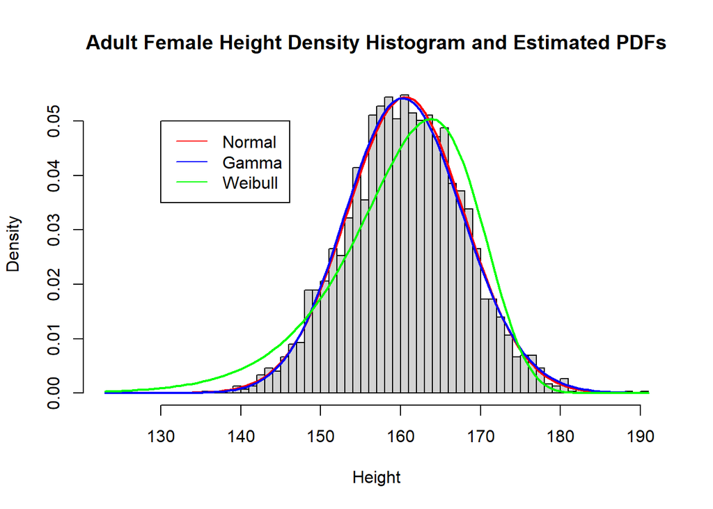

```r
hist(d1$ht, breaks = 50, freq = F,
     main = 'Adult Female Height Density Histogram and Estimated PDFs',
     xlab = 'Height')
curve(dnorm(x, mean = mle_norm_mean, sd = mle_norm_sd), add = T, col = 'red', lwd = 2)
curve(dgamma(x, shape = mle_gamma_shape, scale = mle_gamma_scale), add = T, col = 'blue', lwd = 2)
curve(dweibull(x, shape = mle_weib_shape, scale = mle_weib_scale), add = T, col = 'green', lwd = 2)
legend(130, .05, legend = c('Normal', 'Gamma', 'Weibull'), col = c('red', 'blue', 'green'), lty = 1)
```

From the overlay of the density estimates onto the height PDF, we observe that both normal and gamma distribution estimates appear to be good fits for the actual distribution. Weibull appears to be shifted further right and overestimate densities for the left tail and underestimate densities for the right tail.

### Overlay estimated CDF onto eCDF

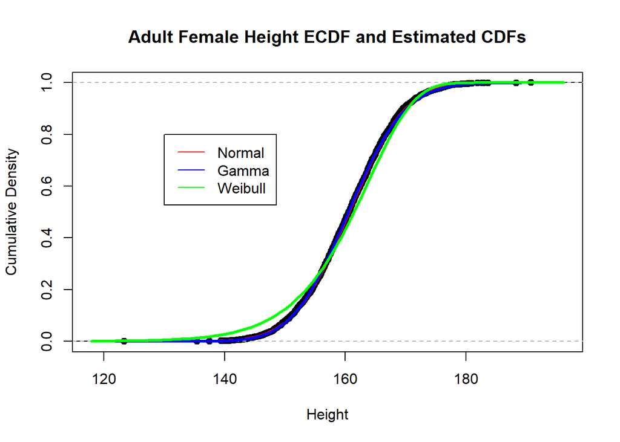

```r
plot(ecdf(d1$ht),
     main = 'Adult Female Height ECDF and Estimated CDFs',
     xlab = 'Height',
     ylab = 'Cumulative Density')
curve(pnorm(x, mean = mle_norm_mean, sd = mle_norm_sd), add = T, col = 'red', lwd = 3)
curve(pgamma(x, shape = mle_gamma_shape, scale = mle_gamma_scale), add = T, col = 'blue', lwd = 3)
curve(pweibull(x, shape = mle_weib_shape, scale = mle_weib_scale), add = T, col = 'green', lwd = 3)
legend(130, .8, legend = c('Normal', 'Gamma', 'Weibull'), col = c('red', 'blue', 'green'), lty = 1)
```

From the above plot of the CDF estimates against the ECDF, our findings from the previous histogram and PDF plot are further confirmed. Normal and gamma estimates appear as good fits while weibull is inaccurate, especially on the left tail.

### QQ plot (sample vs estimated dist)

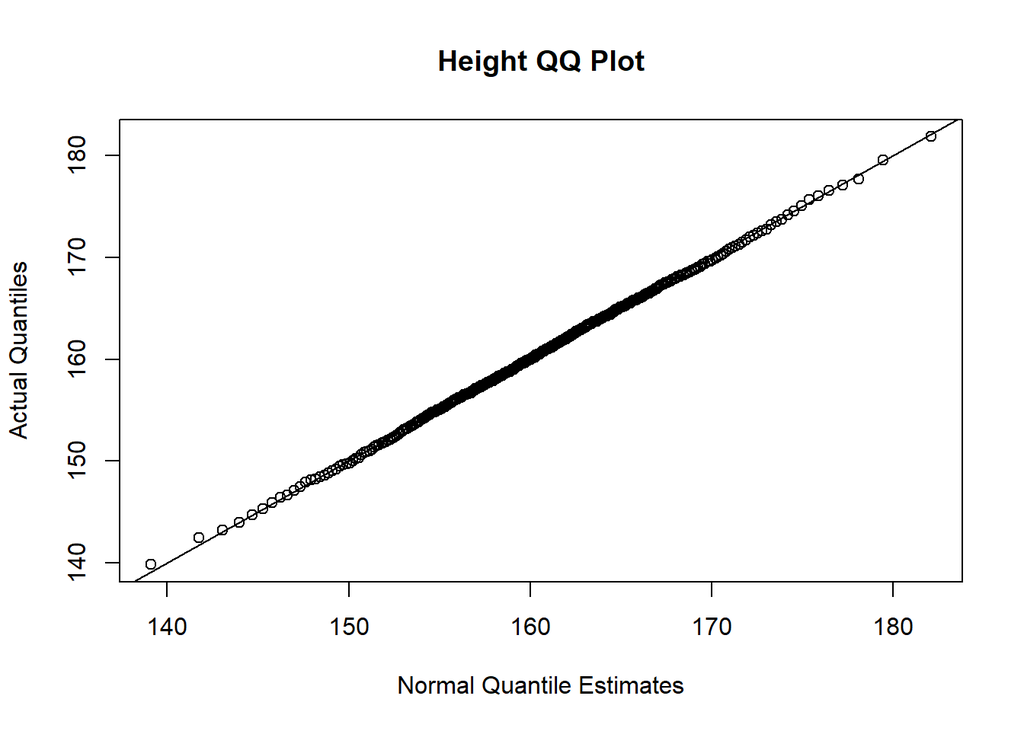

```r
p = ppoints(300)
y = quantile(d1$ht, probs = p)

qqplot(qnorm(p, mean = mle_norm_mean, sd = mle_norm_sd), y,
       main = 'Height QQ Plot',
       xlab = 'Normal Quantile Estimates',
       ylab = 'Actual Quantiles')
abline(0,1)
```

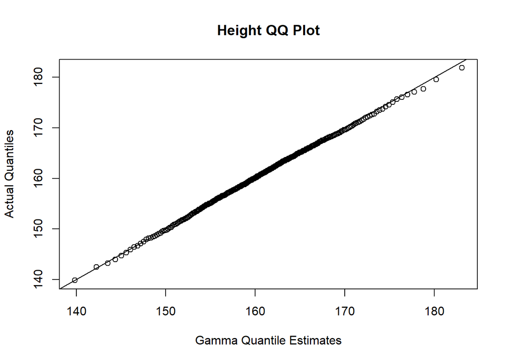

```r
qqplot(qgamma(p, shape = mle_gamma_shape, scale = mle_gamma_scale), y,
       main = 'Height QQ Plot',
       xlab = 'Gamma Quantile Estimates',
       ylab = 'Actual Quantiles')
abline(0,1)
```

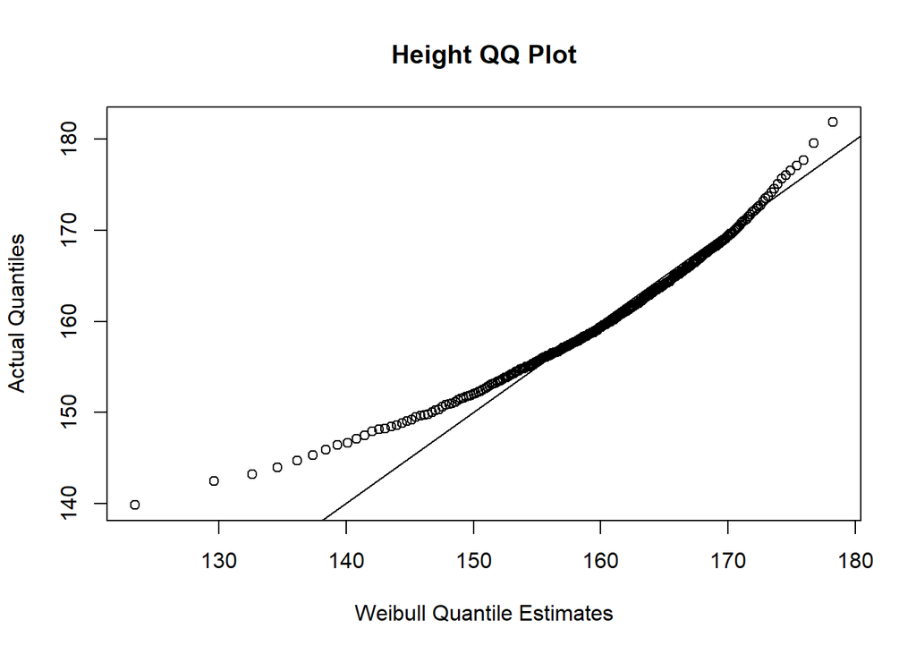

```r
qqplot(qweibull(p, shape = mle_weib_shape, scale = mle_weib_scale), y,
       main = 'Height QQ Plot',
       xlab = 'Weibull Quantile Estimates',
       ylab = 'Actual Quantiles')
abline(0,1)
```

The QQ plots again confirm previous findings. Normal and gamma lie along the line of identity while weibull deviates at the tails. Normal appears to be a slightly better fit than gamma at the upper tail, while gamma appears better on the lower tail.

### Estimated Median

The median of each distribution is calculated by finding the quantile value at .5 for each distribution. The median for the normal estimate is almost exactly that of the actual sample. Gamma is also close to the actual median and weibull is pretty far off, comparatively.

```r
medians <- cbind(c('Actual', 'Normal', 'Gamma', 'Weibull'),
      c(median(d1$ht) %>% round(3),
        qnorm(.5, mean = mle_norm_mean, sd = mle_norm_sd) %>% round(3),
        qgamma(.5, shape = mle_gamma_shape, scale = mle_gamma_scale) %>% round(3),
        qweibull(.5, shape = mle_weib_shape, scale = mle_weib_scale) %>% round(3))) %>% as.data.frame()

medians[,2] <- medians[,2] %>% as.numeric()

names(medians) <- c('Distribution Estimate', 'Median')

kable(medians)
```

| Distribution Estimate | Median |
| --- | --- |
| Actual | 160.600 |
| Normal | 160.601 |
| Gamma | 160.489 |
| Weibull | 161.435 |

### Median Samp Dist (hist)

```r
medians_norm <- NA
for(i in 1:10000) {
  medians_norm[i] = rnorm(nrow(d1), mean = mle_norm_mean, sd = mle_norm_sd) %>% median()
}

medians_gamma <- NA
for(i in 1:10000) {
  medians_gamma[i] = rgamma(nrow(d1), shape = mle_gamma_shape, scale = mle_gamma_scale) %>% median()
}

medians_weib <- NA
for(i in 1:10000) {
  medians_weib[i] = rweibull(nrow(d1), shape = mle_weib_shape, scale = mle_weib_scale) %>% median()
}
```

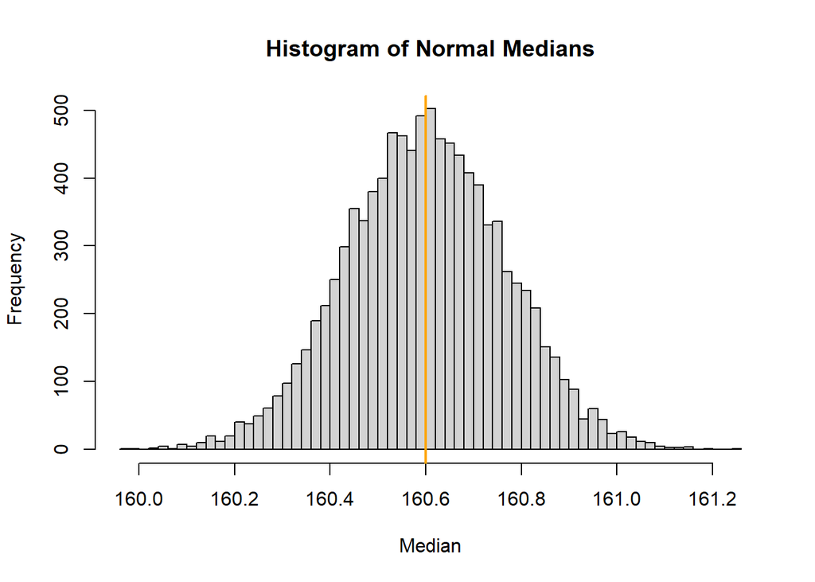

```r
hist(medians_norm, breaks = 50,
     main = 'Histogram of Normal Medians',
     xlab = 'Median')
abline(v = median(d1$ht), col = 'orange', lwd = 2)
```

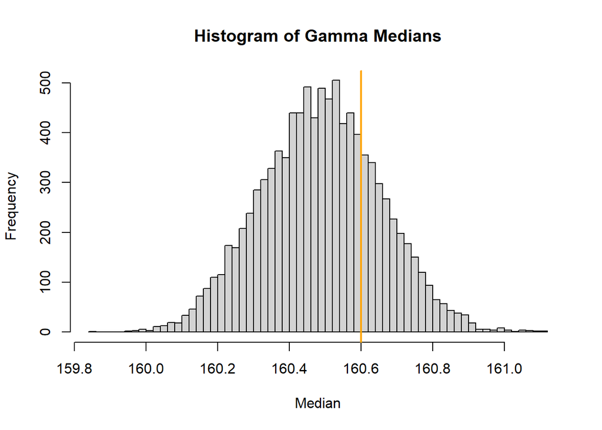

```r
hist(medians_gamma, breaks = 50,
     main = 'Histogram of Gamma Medians',
     xlab = 'Median')
abline(v = median(d1$ht), col = 'orange', lwd = 2)
```

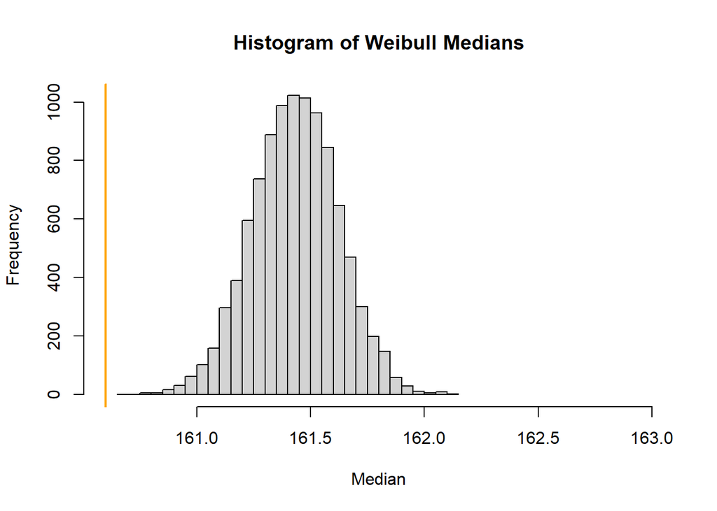

```r
hist(medians_weib, breaks = 50, xlim = c(median(d1$ht), 163),
     main = 'Histogram of Weibull Medians',
     xlab = 'Median')
abline(v = median(d1$ht), col = 'orange', lwd = 2)
```

Once again using simulation to generate median, we observe the estimated median sampling distribution as compared to the actual median. The normal distribution captures the actual median in the center of its sampling distribution. Gamma also captures the actual median, however gamma median values tend to lie lower than the actual median. Weibull fails to capture the actual median in this simulation.

### Range of middle 95% of Median Samp Dist

```r
dist_est <- c('Normal', 'Gamma', 'Weibull')
middle_95 <- rbind(quantile(medians_norm, probs = c(.025, .975)),
                   quantile(medians_gamma, probs = c(.025, .975)),
                   quantile(medians_weib, probs = c(.025, .975))) %>% as.data.frame()

middle_95_dist <- cbind(dist_est, middle_95) %>%
  mutate(`Distribution Estimate` = dist_est,
         `2.5%` = `2.5%` %>% round(3),
         `97.5%` = `97.5%` %>% round(3),
         Range = `97.5%` - `2.5%`,
         `Actual Median Contained` = ifelse(`2.5%` <= median(d1$ht) & `97.5%` >= median(d1$ht), T, F)) %>%
  select(`Distribution Estimate`, `2.5%`, `97.5%`, Range, `Actual Median Contained`)

kable(middle_95_dist)
```

| Distribution Estimate | 2.5% | 97.5% | Range | Actual Median Contained |
| --- | --- | --- | --- | --- |
| Normal | 160.274 | 160.923 | 0.649 | TRUE |
| Gamma | 160.166 | 160.814 | 0.648 | TRUE |
| Weibull | 161.060 | 161.803 | 0.743 | FALSE |

We can calculate the middle 95% of the median sampling distributions by taking the quantiles at .025 and .975 for each of the median sampling distributions. We observe the normal and gamma distributions to have similar ranges which both contain the actual median. Meanwhile, the weibull distribution holds a greater interval and lies higher than the normal and gamma intervals. There is accuracy and precision among the normal and gamma intervals, whereas the weibull distribution is inaccurate and less precise.

## MM

### Estimates of Parameters

The method of moments estimates for the distribution parameters for height are found by taking the exact same steps as used for the glycohemoglobin above. The only change is to change the sample of interest to height from glycohemoglobin.

```r
mm_norm_mean <- mean(d1$ht)
mm_norm_sd <- sd(d1$ht)

mm_gamma_shape <- (mean(d1$ht) ^ 2) / var(d1$ht)
mm_gamma_scale <- var(d1$ht) / mean(d1$ht)

weib_lambda <- function(samp_mean, k) {
  samp_mean / gamma(1 + (1 / k))
}

weib_var_func <- function(samp_mean, samp_var, k) {
  ((weib_lambda(samp_mean, k) ^ 2) * (gamma(1 + (2 / k)) - (gamma(1 + (1 / k)) ^ 2))) - samp_var
}

weib_optimize <- optimize(f = function(x) {abs(weib_var_func(samp_mean = mean(d1$ht), samp_var = var(d1$ht), k = x))},
                          lower = 10, upper = 100)

mm_weib_shape <- weib_optimize$minimum

mm_weib_scale <- weib_lambda(samp_mean = mean(d1$ht), k = mm_weib_shape)
```

### Overlay estimated pdf onto histogram

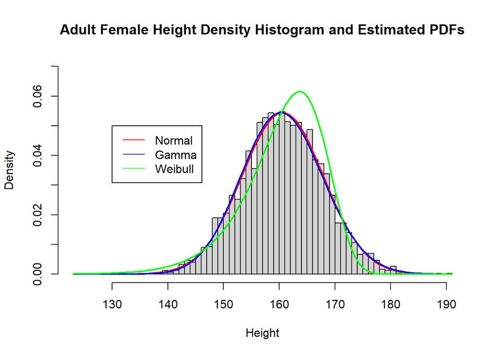

```r
hist(d1$ht, breaks = 50, freq = F, ylim = c(0, .07),
     main = 'Adult Female Height Density Histogram and Estimated PDFs',
     xlab = 'Height')
curve(dnorm(x, mean = mm_norm_mean, sd = mm_norm_sd), add = T, col = 'red', lwd = 2)
curve(dgamma(x, shape = mm_gamma_shape, scale = mm_gamma_scale), add = T, col = 'blue', lwd = 2)
curve(dweibull(x, shape = mm_weib_shape, scale = mm_weib_scale), add = T, col = 'green', lwd = 2)
legend(130, .05, legend = c('Normal', 'Gamma', 'Weibull'), col = c('red', 'blue', 'green'), lty = 1)
```

As with the MLE, from the overlay of the MM density estimates onto the height PDF, we observe that both normal and gamma distribution estimates appear to be good fits for the actual distribution. Weibull appears to be shifted further right and overestimate densities over the 160-170 height interval and at the left tail, while underestimating elsewhere.

### Overlay estimated CDF onto eCDF

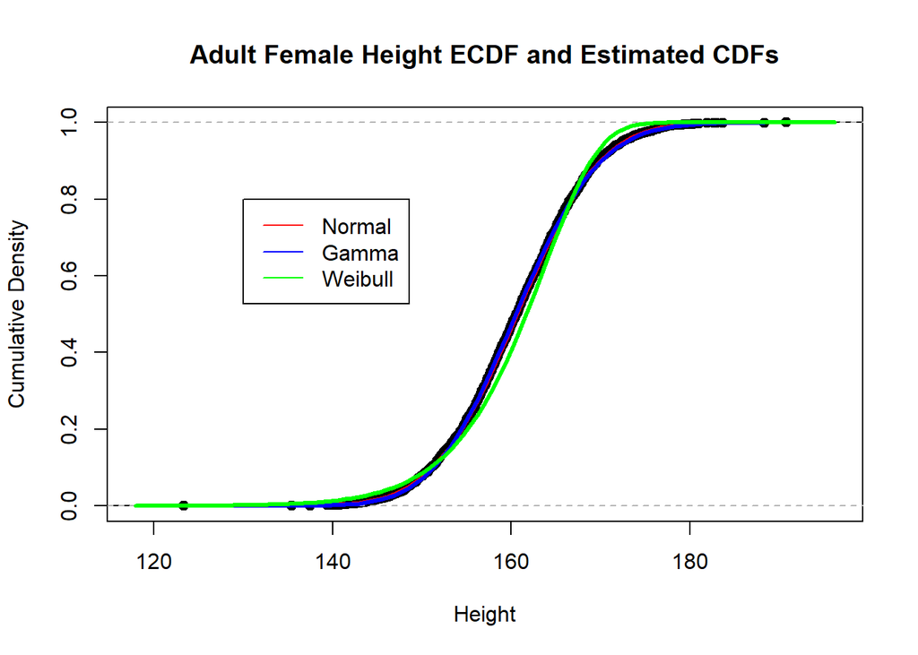

```r
plot(ecdf(d1$ht),
     main = 'Adult Female Height ECDF and Estimated CDFs',
     xlab = 'Height',
     ylab = 'Cumulative Density')
curve(pnorm(x, mean = mm_norm_mean, sd = mm_norm_sd), add = T, col = 'red', lwd = 3)
curve(pgamma(x, shape = mm_gamma_shape, scale = mm_gamma_scale), add = T, col = 'blue', lwd = 3)
curve(pweibull(x, shape = mm_weib_shape, scale = mm_weib_scale), add = T, col = 'green', lwd = 3)
legend(130, .8, legend = c('Normal', 'Gamma', 'Weibull'), col = c('red', 'blue', 'green'), lty = 1)
```

From the above plot of the CDF estimates against the ECDF, our findings from the previous histogram and PDF plot are further confirmed. Normal and gamma estimates appear as good fits while weibull is inaccurate on the intervals previously mentioned.

### QQ plot (sample vs estimated dist)

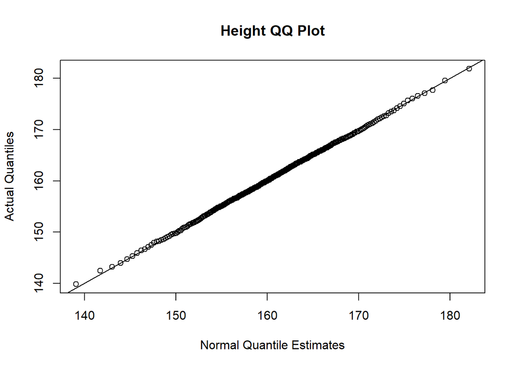

```r
p = ppoints(300)
y = quantile(d1$ht, probs = p)

qqplot(qnorm(p, mean = mm_norm_mean, sd = mm_norm_sd), y,
       main = 'Height QQ Plot',
       xlab = 'Normal Quantile Estimates',
       ylab = 'Actual Quantiles')
abline(0,1)
```

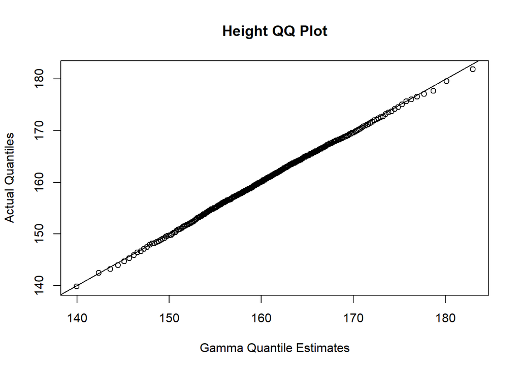

```r
qqplot(qgamma(p, shape = mm_gamma_shape, scale = mm_gamma_scale), y,
       main = 'Height QQ Plot',
       xlab = 'Gamma Quantile Estimates',
       ylab = 'Actual Quantiles')
abline(0,1)
```

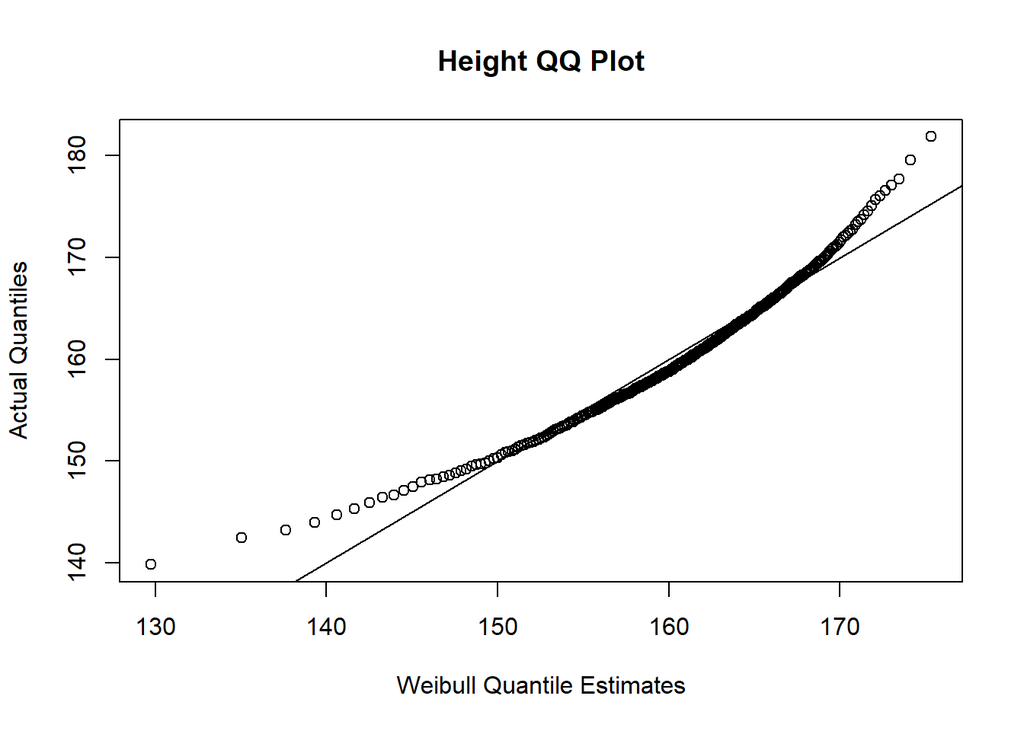

```r
qqplot(qweibull(p, shape = mm_weib_shape, scale = mm_weib_scale), y,
       main = 'Height QQ Plot',
       xlab = 'Weibull Quantile Estimates',
       ylab = 'Actual Quantiles')
abline(0,1)
```

The QQ plots again confirm previous findings. Normal and gamma lie along the line of identity while weibull deviates over the previously mentioned intervals. Normal appears to be a slightly better fit than gamma at the upper tail, while gamma appears better on the lower tail.

### Estimated Median

The median of each distribution is calculated by finding the quantile value at .5 for each distribution. The median values for the normal and gamma distributions generated by MM are identical to those generated by MLE. The median for the normal estimate is almost exactly that of the actual sample. Gamma is also close to the actual median and weibull is pretty far off, comparatively.

```r
medians <- cbind(c('Actual', 'Normal', 'Gamma', 'Weibull'),
      c(median(d1$ht) %>% round(3),
        qnorm(.5, mean = mm_norm_mean, sd = mm_norm_sd) %>% round(3),
        qgamma(.5, shape = mm_gamma_shape, scale = mm_gamma_scale) %>% round(3),
        qweibull(.5, shape = mm_weib_shape, scale = mm_weib_scale) %>% round(3))) %>% as.data.frame()

medians[,2] <- medians[,2] %>% as.numeric()

names(medians) <- c('Distribution Estimate', 'Median')

kable(medians)
```

| Distribution Estimate | Median |
| --- | --- |
| Actual | 160.600 |
| Normal | 160.601 |
| Gamma | 160.489 |
| Weibull | 161.666 |

### Median Samp Dist (hist)

```r
medians_norm <- NA
for(i in 1:10000) {
  medians_norm[i] = rnorm(nrow(d1), mean = mm_norm_mean, sd = mm_norm_sd) %>% median()
}

medians_gamma <- NA
for(i in 1:10000) {
  medians_gamma[i] = rgamma(nrow(d1), shape = mm_gamma_shape, scale = mm_gamma_scale) %>% median()
}

medians_weib <- NA
for(i in 1:10000) {
  medians_weib[i] = rweibull(nrow(d1), shape = mm_weib_shape, scale = mm_weib_scale) %>% median()
}
```

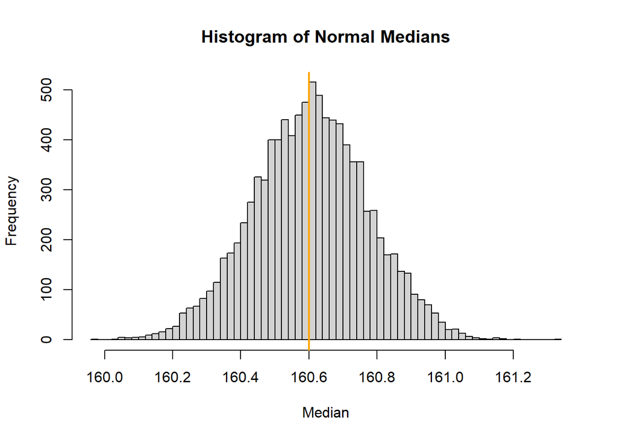

```r
hist(medians_norm, breaks = 50,
     main = 'Histogram of Normal Medians',
     xlab = 'Median')
abline(v = median(d1$ht), col = 'orange', lwd = 2)
```

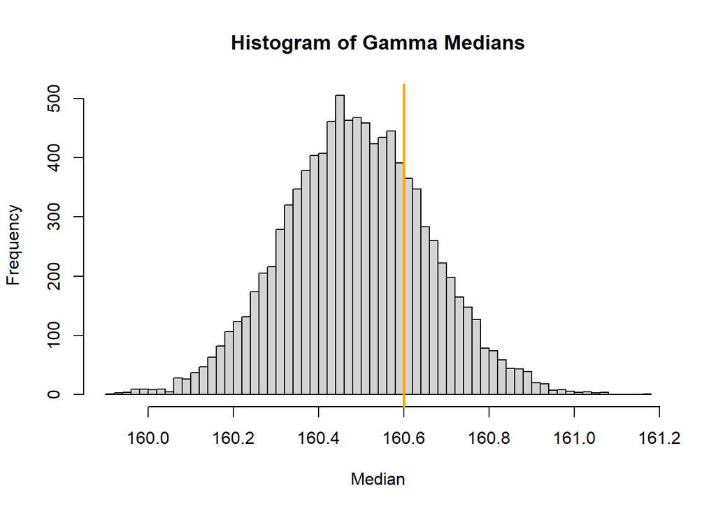

```r
hist(medians_gamma, breaks = 50,
     main = 'Histogram of Gamma Medians',
     xlab = 'Median')
abline(v = median(d1$ht), col = 'orange', lwd = 2)
```

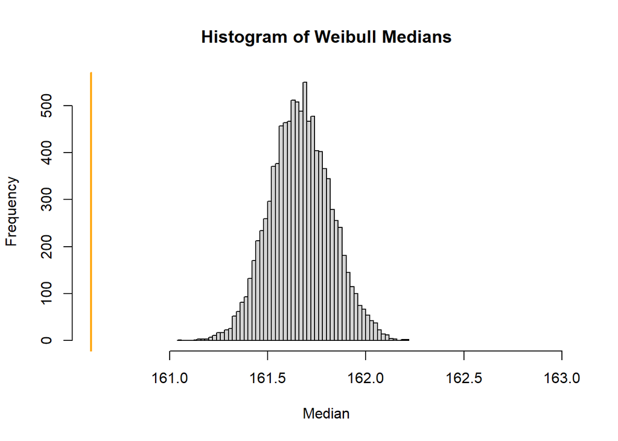

```r
hist(medians_weib, breaks = 50, xlim = c(median(d1$ht), 163),
     main = 'Histogram of Weibull Medians',
     xlab = 'Median')
abline(v = median(d1$ht), col = 'orange', lwd = 2)
```

Once again using simulation to generate median, we observe the estimated median sampling distribution as compared to the actual median. The results are very similar to those generated by the MLE approach. The normal distribution captures the actual median in the center of its sampling distribution. Gamma also captures the actual median, however gamma median values tend to lie lower than the actual median. Weibull fails to capture the actual median in this simulation - to an even greater extent with MM than with MLE.

### Range of middle 95% of Median Samp Dist

```r
dist_est <- c('Normal', 'Gamma', 'Weibull')
middle_95 <- rbind(quantile(medians_norm, probs = c(.025, .975)),
                   quantile(medians_gamma, probs = c(.025, .975)),
                   quantile(medians_weib, probs = c(.025, .975))) %>% as.data.frame()

middle_95_dist <- cbind(dist_est, middle_95) %>%
  mutate(`Distribution Estimate` = dist_est,
         `2.5%` = `2.5%` %>% round(3),
         `97.5%` = `97.5%` %>% round(3),
         Range = `97.5%` - `2.5%`,
         `Actual Median Contained` = ifelse(`2.5%` <= median(d1$ht) & `97.5%` >= median(d1$ht), T, F)) %>%
  select(`Distribution Estimate`, `2.5%`, `97.5%`, Range, `Actual Median Contained`)

kable(middle_95_dist)
```

| Distribution Estimate | 2.5% | 97.5% | Range | Actual Median Contained |
| --- | --- | --- | --- | --- |
| Normal | 160.269 | 160.937 | 0.668 | TRUE |
| Gamma | 160.161 | 160.823 | 0.662 | TRUE |
| Weibull | 161.365 | 161.983 | 0.618 | FALSE |

We can calculate the middle 95% of the median sampling distributions by taking the quantiles at .025 and .975 for each of the median sampling distributions. We observe the normal and gamma distributions to have similar ranges which both contain the actual median. Meanwhile, the weibull distribution holds a tighter range, but does not contain the actual median. There is greater precision for the median sampling distribution for weibull than with the normal and gamma, however the normal and gamma distributions are accurate while the weibull is not.

## Height Takeaways

We see that distribution estimates of height generated by both MLE and MM are good fits for both the normal and gamma distributions. Based on the different observations for each distribution, normal is probably the best distribution for height - it edges the gamma distribution out when looking at the simulated sampling distribution of medians. Regardless of method, normal is clearly the best distribution to represent height.

# Overall Takeaways

Overall, we see that for both MLE and MM did not provide good fits for glycohemoglobin when testing the normal, gamma, and weibull distributions. However, for height we observed that normal is the best distributive fit out of the three, regardless of the method used. This displays the interchangeability of methods as long as the distribution used is correct. The normal distribution worked for the height variable for both MLE and MM because it was a good distributive fit, the path chosen to get there (MLE or MM) does not matter. In order to evaluate the fit of distributions, you should observe several factors before coming to a final decision: probability density fit, cumulative density fit, quantile fit, median fit. While two distributions may seem like good fits in any one of these factors, observing these factors all together should provide a clear answer of the correct distribution to use (as was seen in the normal and gamma height comparison - medians ended up being the tiebreaker).